# Projeto4

Fernando

April 9, 2017

# Introducao

O presente trabalho tem como objetivo o estudo da base de dados [2016 Presidential Campaign Finance](http://fec.gov/disclosurep/pnational.do) que reune dados de doacoes para campanhas de diversos candidatos. Os pontos que valem a pena serem destacados sao:

1. Os dados utilizados sao do estado da California
2. Existe somente uma variavel numerica, sendo as demais categoricas
3. O arquivo possui mais de 1 milhao de linhas
4. Existem doacoes negativas que precisaram serem tratadas

O trabalho foca nos principais candidatos e na origem das suas doacoes para entender como a ocupacao de cada doador esta relacionada a escolha do seu candidato.

# Importacao dos dados

Nomes de colunas sao gerados de forma automatica.

Amostra dos dados

| row.names | cmte_id | cand_id | cand_nm | contbr_nm | contbr_city | contbr_st | contbr_zip | contbr_employer | contbr_occupation | contb_receipt_amt | contb_receipt_dt | receipt_desc | memo_cd | memo_text | form_tp | file_num | tran_id | election_tp |
| --- | --- | --- | --- | --- | --- | --- | --- | --- | --- | --- | --- | --- | --- | --- | --- | --- | --- | --- |
| C00575795 | P00003392 | Clinton, Hillary Rodham | AULL, ANNE | LARKSPUR | CA | 949391913 | N/A | RETIRED | 50.00 | 26-APR-16 |  | X | * HILLARY VICTORY FUND | SA18 | 1091718 | C4768722 | P2016 | NA |
| C00575795 | P00003392 | Clinton, Hillary Rodham | CARROLL, MARYJEAN | CAMBRIA | CA | 934284638 | N/A | RETIRED | 200.00 | 20-APR-16 |  | X | * HILLARY VICTORY FUND | SA18 | 1091718 | C4747242 | P2016 | NA |
| C00575795 | P00003392 | Clinton, Hillary Rodham | GANDARA, DESIREE | FONTANA | CA | 923371507 | N/A | RETIRED | 5.00 | 02-APR-16 |  | X | * HILLARY VICTORY FUND | SA18 | 1091718 | C4666603 | P2016 | NA |
| C00580100 | P80001571 | Trump, Donald J. | RODACY, JON | LIVINGSTON | CA | 95334 | INFORMATION REQUESTED | INFORMATION REQUESTED | 48.33 | 21-NOV-16 |  | X |  | SA18 | 1146165 | SA18.177204 | G2016 | NA |
| C00577130 | P60007168 | Sanders, Bernard | LEE, ALAN | CAMARILLO | CA | 930111214 | AT&T GOVERNMENT SOLUTIONS | SOFTWARE ENGINEER | 40.00 | 04-MAR-16 |  |  | * EARMARKED CONTRIBUTION: SEE BELOW | SA17A | 1077404 | VPF7BKWA097 | P2016 | NA |
| C00580100 | P80001571 | Trump, Donald J. | ROONEY, JULIANNE | SACRAMENTO | CA | 95826 | INFORMATION REQUESTED | INFORMATION REQUESTED | 244.34 | 24-NOV-16 |  | X |  | SA18 | 1146165 | SA18.79956 | G2016 | NA |

Vemos que a importacao esta com as colunas deslocadas, como exemplo vemos que o estado estao com o zip code, estes campos devem ser corrigidos.

Os campos election_tp,tran_id,form_tp sao campos de controle de fluxo de informacoes (ID’s) e nao serao considerados na analise exploratoria.

# Corrigindo a posicao das colunas

Corrigindo a posicao das colunas e retirando os campos que nao serao utilizados.

Amostra com colunas corrigidas

| cmte_id | cand_id | cand_nm | contbr_nm | contbr_city | contbr_st | contbr_zip | contbr_employer | contbr_occupation | contb_receipt_amt | contb_receipt_dt | receipt_desc | memo_cd | memo_text |
| --- | --- | --- | --- | --- | --- | --- | --- | --- | --- | --- | --- | --- | --- |
| C00575795 | P00003392 | Clinton, Hillary Rodham | AULL, ANNE | LARKSPUR | CA | 949391913 | N/A | RETIRED | 50.00 | 26-APR-16 |  | X | * HILLARY VICTORY FUND |
| C00575795 | P00003392 | Clinton, Hillary Rodham | CARROLL, MARYJEAN | CAMBRIA | CA | 934284638 | N/A | RETIRED | 200.00 | 20-APR-16 |  | X | * HILLARY VICTORY FUND |
| C00575795 | P00003392 | Clinton, Hillary Rodham | GANDARA, DESIREE | FONTANA | CA | 923371507 | N/A | RETIRED | 5.00 | 02-APR-16 |  | X | * HILLARY VICTORY FUND |
| C00580100 | P80001571 | Trump, Donald J. | RODACY, JON | LIVINGSTON | CA | 95334 | INFORMATION REQUESTED | INFORMATION REQUESTED | 48.33 | 21-NOV-16 |  | X |  |
| C00577130 | P60007168 | Sanders, Bernard | LEE, ALAN | CAMARILLO | CA | 930111214 | AT&T GOVERNMENT SOLUTIONS | SOFTWARE ENGINEER | 40.00 | 04-MAR-16 |  |  | * EARMARKED CONTRIBUTION: SEE BELOW |
| C00580100 | P80001571 | Trump, Donald J. | ROONEY, JULIANNE | SACRAMENTO | CA | 95826 | INFORMATION REQUESTED | INFORMATION REQUESTED | 244.34 | 24-NOV-16 |  | X |  |

Agora os campos estao corretos para iniciar a analise.

Podemos que 3 tipos de variaveis:

> **Categoricas**: 12 categoricas

> **Numerica**: Somente *contb_receipt_amt* como o valor doado (em alguns casos negativa)

> **Data**: Somente *contb_receipt_dt* como a data doacao

# Analise Univariada

## Caracteristicas do Data set

Quantidade de colunas e de observacoes.

```
## [1] 14
```

```
## [1] 1304346
```

## Valores negativos

Aqui e nas proximas analises os valores **negativos** serao desconsiderados. Como nao existe documentacao explicando a causa desses valores serem negativos nao temos um tratamento adequado para correcao destes, entao usamos a solucao trivial que e descarta-los.

```
##
## (-1e+04,-5e+03] (-5e+03,-1e+03]   (-1e+03,-500]     (-500,-100]
##              67            2184             991            4779
##        (-100,0]
##            8290
```

```
## [1] "Quantidade de valores negativos:  16313"
```

### Analise de quartil

Como primeiro passo para criar familiaridade com os dados vou utilizar uma analise de quartil. Vemos que 75% das contribuicoes ocorrem ate $99.

```
##    0%   25%   50%   75%  100%
##     0    15    27    99 10800
```

Uma nova analise com mais intervalos e comecando a partir de 75% temos que **95%** das doacoes chegam no maximo a $400 e esse valor pode ser utilizado como limite nas visualizacoes futuras para facilitar o entendimento dos proximos graficos.

```
##   75%   80%   85%   90%   95%  100%
##    99   100   100   200   400 10800
```

## Distribuicao das contribuicoes

Usando o limite de **$400** encontrado anteriomente e criando um histograma vemos que a maioria das doacoes se encontram dentro de um pequeno intervalo de **0-100** dólares.

Como os dados estao muito proximos, transformacao de coordenadas podemos tentar uma transformacao de escala para facilitar a visao.

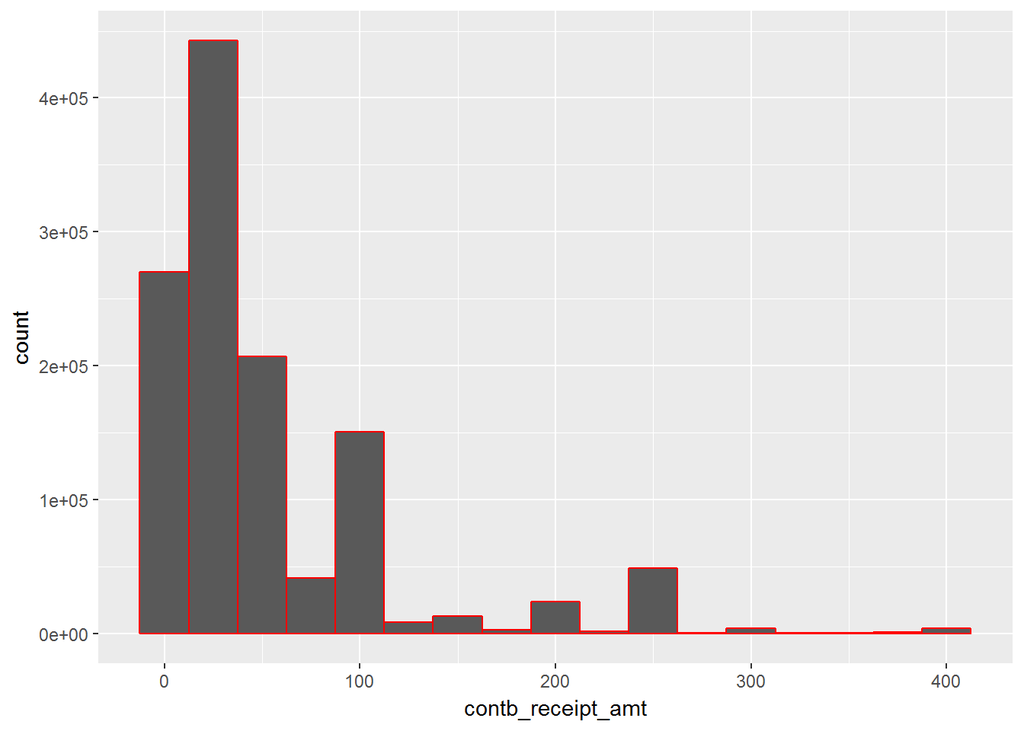

### Distribuicaoo das contribuicoes - Log10

Transformando a escala para **log10** temos uma distribuicao que mostra como os valores das doacoes sao concentrados e podemos visualizar 100% dos dados (anterior foi restrita a $400). Podemos ver que uma quantidade de significativa de contribuicoes ocorre ate **1300** dolares, sendo este um valor mais interessante para usarmos como filtro nos proximos graficos e deixa os valores superiores como **outliers**.

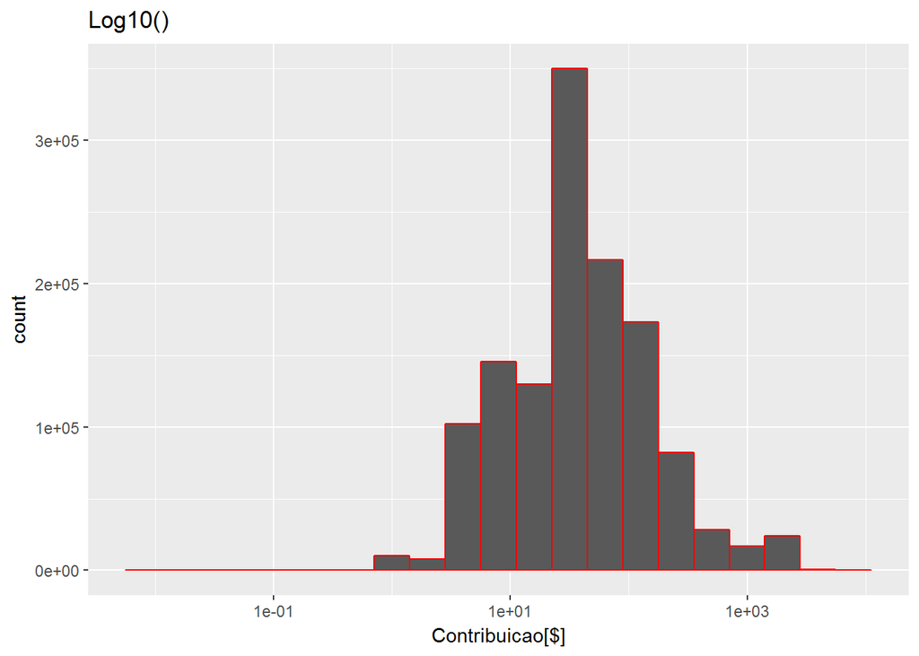

## Destinos das doacoes e distribuicao das doacoes no tempo

Agora que ja entendemos a distribuicao das doacoes e nos familiarzamos com os dados, podemos analisar para onde estas sendo direcionadas as doacoes e como ocorre ao longo do dos dias.

### Destino das doacoes

Analisando o destino das doacoes vemos que Clinton, Hillary Rodham recebeu a maioria das doacoes quando olhamos em quantidade de doadores, seguida por Sanders, Bernard e Trump, Donald J. e que após este último, a quantidade de doacoes cai rapidamente para os demais candidatos.

```
##
##   Clinton, Hillary Rodham          Sanders, Bernard
##                    688524                    407164
##          Trump, Donald J. Cruz, Rafael Edward 'Ted'
##                     86258                     57822
##       Carson, Benjamin S.              Rubio, Marco
##                     27370                     14095
##            Fiorina, Carly                Paul, Rand
##                      4706                      4279
##                 Bush, Jeb           Kasich, John R.
##                      3130                      3005
##               Stein, Jill             Johnson, Gary
##                      2842                      1758
##             Walker, Scott            Huckabee, Mike
##                       740                       531
##   O'Malley, Martin Joseph          Lessig, Lawrence
##                       397                       372
##        Graham, Lindsey O.  Christie, Christopher J.
##                       347                       333
##            McMullin, Evan    Perry, James R. (Rick)
##                       306                       116
##     Webb, James Henry Jr.      Santorum, Richard J.
##                       106                        91
##             Jindal, Bobby         Pataki, George E.
##                        31                        20
##      Gilmore, James S III
##                         3
```

Analisando as proporcoes.

```
##                         Name            Proporcao.Var1 Proporcao.Freq
## 1    Clinton, Hillary Rodham   Clinton, Hillary Rodham           0.53
## 2           Sanders, Bernard          Sanders, Bernard           0.31
## 3           Trump, Donald J.          Trump, Donald J.           0.07
## 4  Cruz, Rafael Edward 'Ted' Cruz, Rafael Edward 'Ted'           0.04
## 5        Carson, Benjamin S.       Carson, Benjamin S.           0.02
## 6               Rubio, Marco              Rubio, Marco           0.01
## 7             Fiorina, Carly            Fiorina, Carly           0.00
## 8                 Paul, Rand                Paul, Rand           0.00
## 9                  Bush, Jeb                 Bush, Jeb           0.00
## 10           Kasich, John R.           Kasich, John R.           0.00
## 11               Stein, Jill               Stein, Jill           0.00
## 12             Johnson, Gary             Johnson, Gary           0.00
## 13             Walker, Scott             Walker, Scott           0.00
## 14            Huckabee, Mike            Huckabee, Mike           0.00
## 15   O'Malley, Martin Joseph   O'Malley, Martin Joseph           0.00
## 16          Lessig, Lawrence          Lessig, Lawrence           0.00
## 17        Graham, Lindsey O.        Graham, Lindsey O.           0.00
## 18  Christie, Christopher J.  Christie, Christopher J.           0.00
## 19            McMullin, Evan            McMullin, Evan           0.00
## 20    Perry, James R. (Rick)    Perry, James R. (Rick)           0.00
## 21     Webb, James Henry Jr.     Webb, James Henry Jr.           0.00
## 22      Santorum, Richard J.      Santorum, Richard J.           0.00
## 23             Jindal, Bobby             Jindal, Bobby           0.00
## 24         Pataki, George E.         Pataki, George E.           0.00
## 25      Gilmore, James S III      Gilmore, James S III           0.00
```

## Visualizando a tabela anterior

Criando um histograma da tabela anterior vemos os candidatos expressivos no estado da California. Vemos que na California a quantidade de doadores foi muito superior para Hillary Clinton e Bernard Sanders que possuem caracteristicas politicas proximas, sendo Hillary de centro e Sanders algo mais proximo com a esquerda.

Poderiamos utilizar somente os dois primeiros candidatos para as proximas analises devido a sua representatividade, mas como representam visoes politicas proximas a inclusao de Trump, Donald J. permite uma analise de preferencias politicas mais amplo devido a este candidato ser **republicano**.

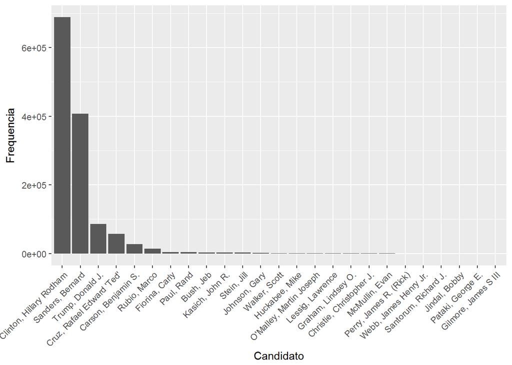

### Distribuicao das doacoes no tempo

Como analise complementar ao destino das doacoes podemos explorar como as doacoes se distribuem no tempo. Nas secoes de analise bivariada e multivariada a frequencia de doacao pode nos ajudar a entender como cada ocupacao faz sua doacao, no inicio, meio ou final da campanha.

As doacoes sao distribuidas no tempo se concentram no ano de 2016 (ano de eleicao) com periodos de maior concentracao nos primeiros meses de 2016 e nos meses que antecedem o dia de votacao. Nas proximas analises com mais variaveis esta visulizacao pode ser enriquecida com dados das ocupacoes e candidatos.

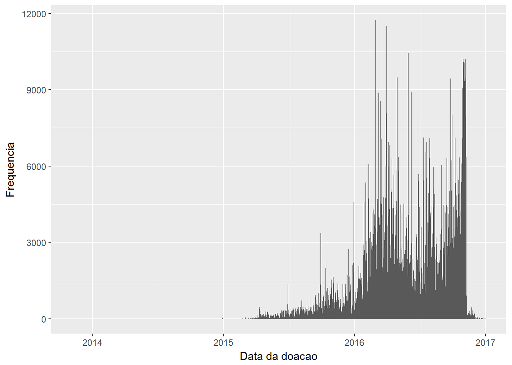

## Analisando a ocupacao dos contribuidores

A partir daqui podemos estabelecer varias analises da origem da contribuicao por candidato e periodo do ano, além de como cada grupo de contribuintes concentra suas preferencias.

Os contribuintes serao agrupados em ocupacoes declaradas, mas devido a grande quantidade de ocupacoes iremos restringir as com maior frequencia de doacoes.

### Ocupacoes - Estatisticas

Estatisticas sobre ocupacoes:

```
## [1] "Numero de ocupacoes declaradas:  28623"
```

```
##                      Contagem Proporcao
## Ocupacao de 0 ateh 9   539120      0.41
## De 10 ateh 90          302915      0.23
## De 91 ateh 10000       420267      0.32
## De 10001 ateh 28622     41903      0.03
```

Vemos que o numero de ocupacoes declaradas sao 28623 e que ao agruparmos as ocupacoes apos ordenadas em ordem descrescente, vemos que as 9 primeiras ocupacoes representam 41% das doacoes e em seguida ocorre uma grande diluicao das doacores por ocupacao.

Seria inviavel trabalhar com todas as ocupacoes devido a base de dados pequena para maioria delas, entao o presente trabalho vai se concentrar nas 9 primeiras e agrupar as demais na ocupacao denominada “Outras, assim teremos: > 9 ocupacoes que representam 41% dos dados

> 1 ocupacao chamada “Outras” representando 59% dos dados

### Ocupacoes ajustadas

As 09 principais ocupacoes sao identificadas e as demais agrupadas em “Outras” e consolidando a base em 10 ocupacoes.

No grafico de ocupacoes vemos que a maior ocupacao e “Outras”, ou seja, a quantidade de ocupacoes declaradas e grande e quando agrupamos as ocupacoes que nao fazem parte das **9 primeiras** esse agrupamento se torna a primeira ocupacao.

Interessante que em numeros de doacoes os principais sao aposentados e desempregados, talvez por serem a parte da populacao que se sente pressionada por decisoes politicas.

```
##
##                Outras               RETIRED          NOT EMPLOYED
##                765226                260546                115598
##              ATTORNEY INFORMATION REQUESTED               TEACHER
##                 36640                 30948                 29104
##              ENGINEER             HOMEMAKER             PHYSICIAN
##                 17749                 17268                 16111
##     SOFTWARE ENGINEER
##                 15156
```

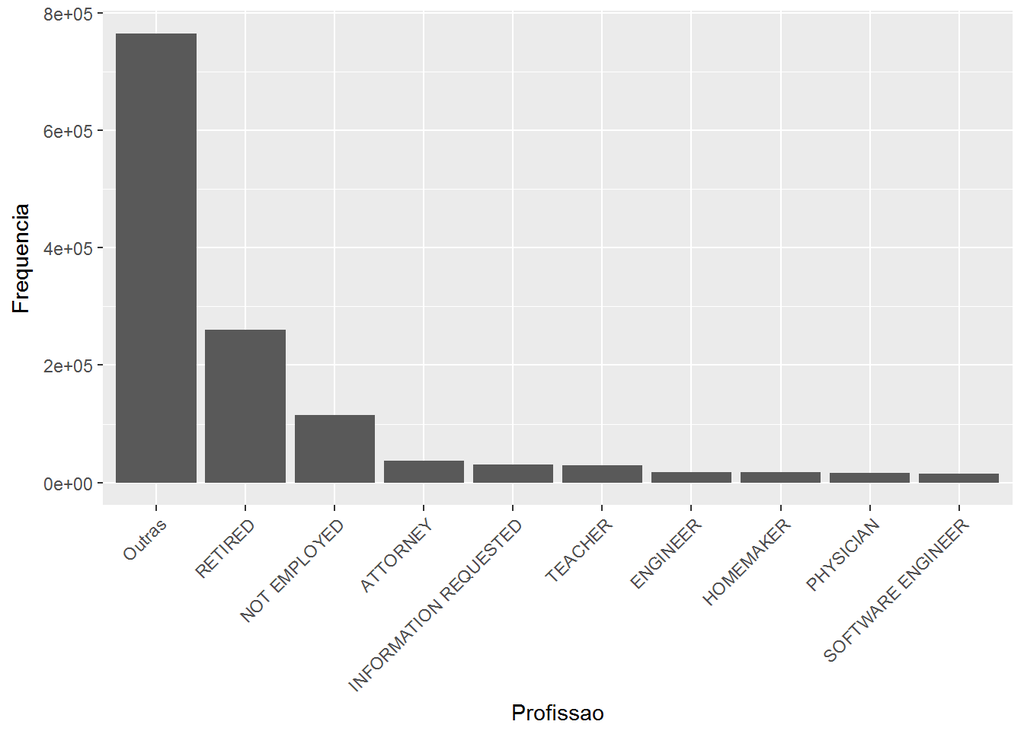

# Analise Bivariada

## Preparacao

Temos que pelas analises univariadas que existem 3 candidatos que possuem a maior parte das doacoes, Hillary, Senders e Trump (eleito) e varios doadores de pequenas quantias e que possuem varias profissoes, assim podemos comecar a analisar de forma bivariada a relacao entre doadores e candidatos atraves do tamanho da doacao e da profissao.

Outras caracteristicas que podemos explorar seriam as cidades de origem das doacoes por volume de contribuicao e profissoes.

Com a analise bivariada bem estabelecida podemos nos aprofundar em relacoes multivariadas.

## Distribuicao das contribuicoes por candidato

Um analise simples e direta e tentar visualizar a relacao do candidato com as doacoes que ele recebeu. Isso permite verificar se existe alguma tendencia na doacoes.

Pelo gráfico as doacoes possuem a mesma distribuicao. A diferenca esta na quantidade de doacoes vista no grafico abaixo que usa alpha = 1/30 para mostrar onde os dados se sobrepoem, com isso não podemos supor algum padrao.

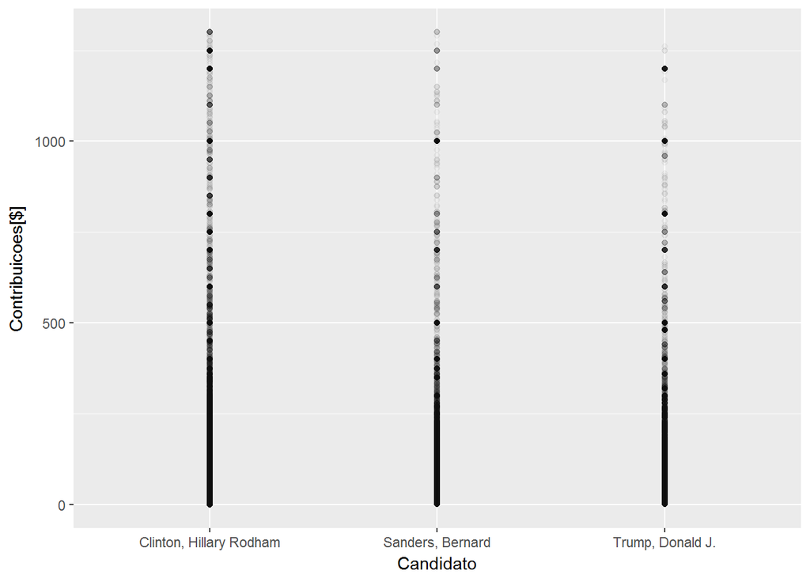

## Reduzindo quantidade de variaveis e filtrando as observacoes

Tabela filtrada nos 3 principais candidatos

| cand_nm | contbr_nm | contbr_city | contbr_st | contbr_employer | contbr_occupation | contb_receipt_amt | contb_receipt_dt | receipt_desc | memo_cd | memo_text | profissao |
| --- | --- | --- | --- | --- | --- | --- | --- | --- | --- | --- | --- |
| Clinton, Hillary Rodham | AULL, ANNE | LARKSPUR | CA | N/A | RETIRED | 50.00 | 2016-04-26 |  | X | * HILLARY VICTORY FUND | RETIRED |
| Clinton, Hillary Rodham | CARROLL, MARYJEAN | CAMBRIA | CA | N/A | RETIRED | 200.00 | 2016-04-20 |  | X | * HILLARY VICTORY FUND | RETIRED |
| Clinton, Hillary Rodham | GANDARA, DESIREE | FONTANA | CA | N/A | RETIRED | 5.00 | 2016-04-02 |  | X | * HILLARY VICTORY FUND | RETIRED |
| Trump, Donald J. | RODACY, JON | LIVINGSTON | CA | INFORMATION REQUESTED | INFORMATION REQUESTED | 48.33 | 2016-11-21 |  | X |  | INFORMATION REQUESTED |
| Sanders, Bernard | LEE, ALAN | CAMARILLO | CA | AT&T GOVERNMENT SOLUTIONS | SOFTWARE ENGINEER | 40.00 | 2016-03-04 |  |  | * EARMARKED CONTRIBUTION: SEE BELOW | SOFTWARE ENGINEER |
| Trump, Donald J. | ROONEY, JULIANNE | SACRAMENTO | CA | INFORMATION REQUESTED | INFORMATION REQUESTED | 244.34 | 2016-11-24 |  | X |  | INFORMATION REQUESTED |

## Analisando os contribuintes por profissao declarada

Nas visualizacoes anteriores percebemos que as doacoes se concentram em pequenos valores e que a quantidade de doacoes depende da ocupacao, agora comparando valor das doacoes com a ocupacao podemos entender como se distrbuem o valor das doacoes e se alguma ocupacao tem tendencia a fazer doacoes maiores ou menores. Esse tipo de analise pode indicar um publico que pode aumentar a arrecadacao de campanha se seus interesses forem colocados em pauta.

### Resultado

Vemos (gráficos abaixo) que nao importa o contribuinte o perfil de doacao e semelhante em ambos os casos, exceto para os que *nao informaram a ocupacao*, onde podemos ver que ao contrário dos demais a quantidade de doacoes dentro da faixa de $50-$100 e $100-$150 esta maior que na faixa $0-$50. **observacao** cada bin tem largura de $50.

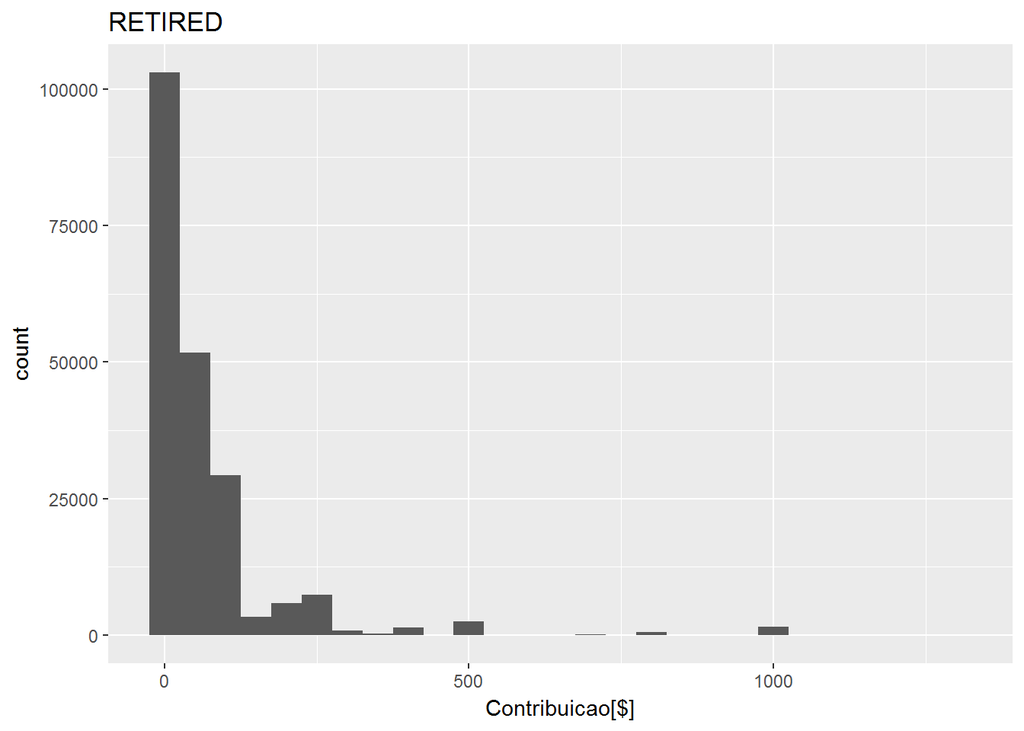

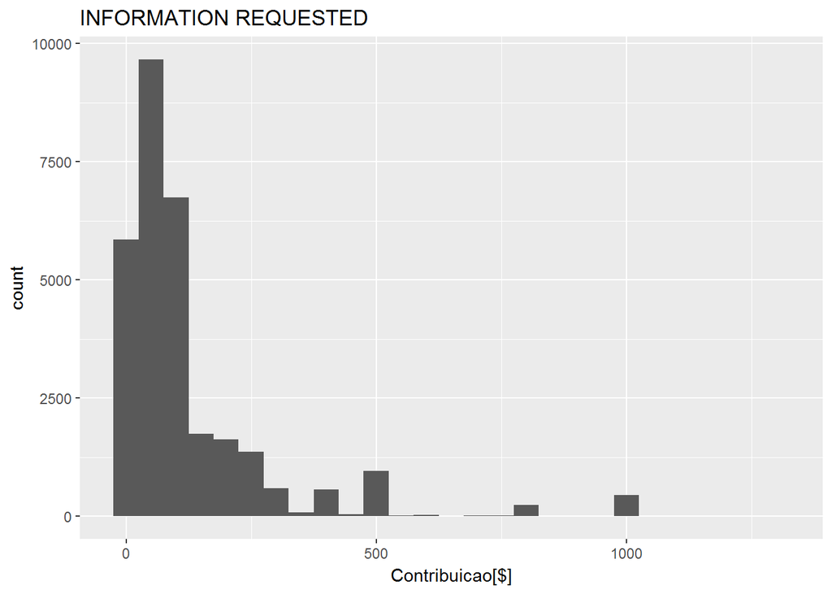

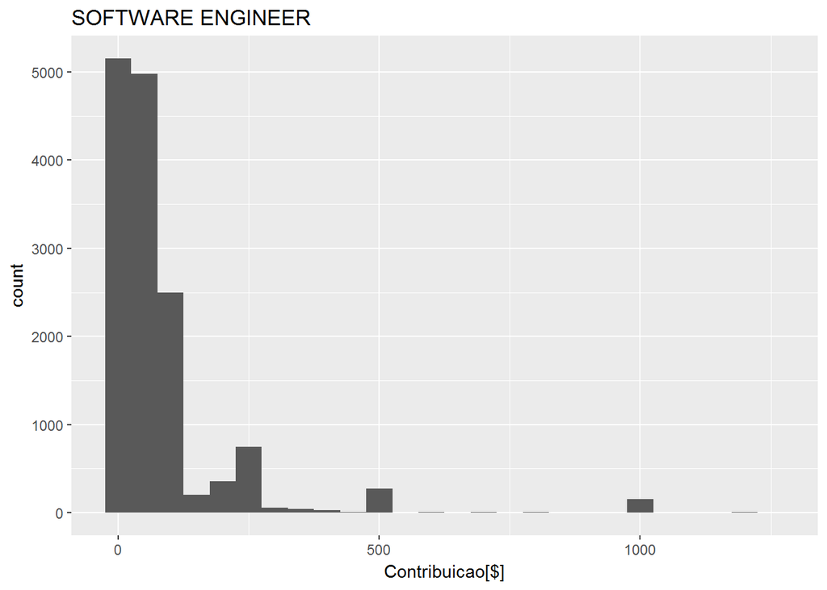

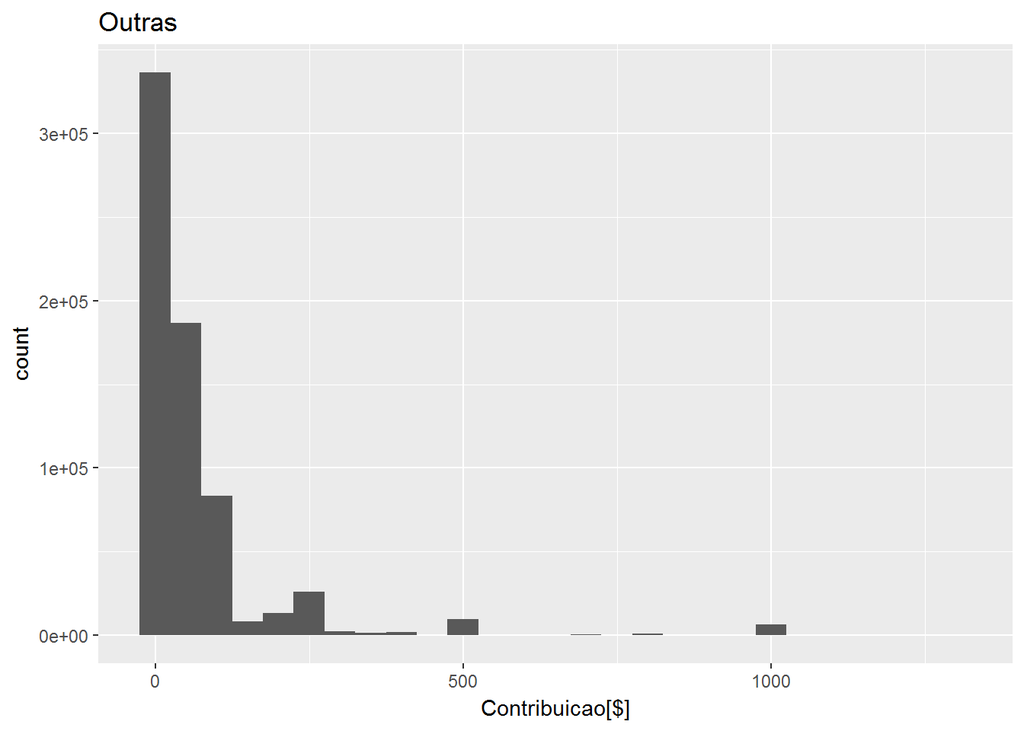

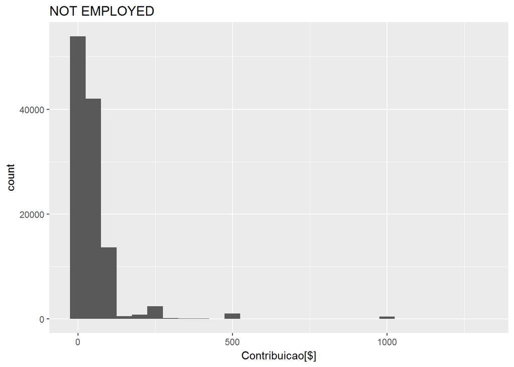

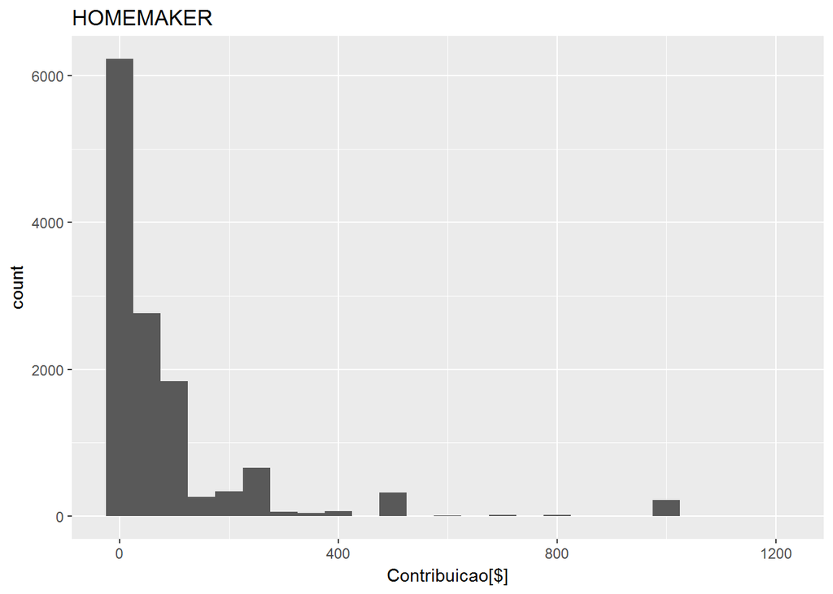

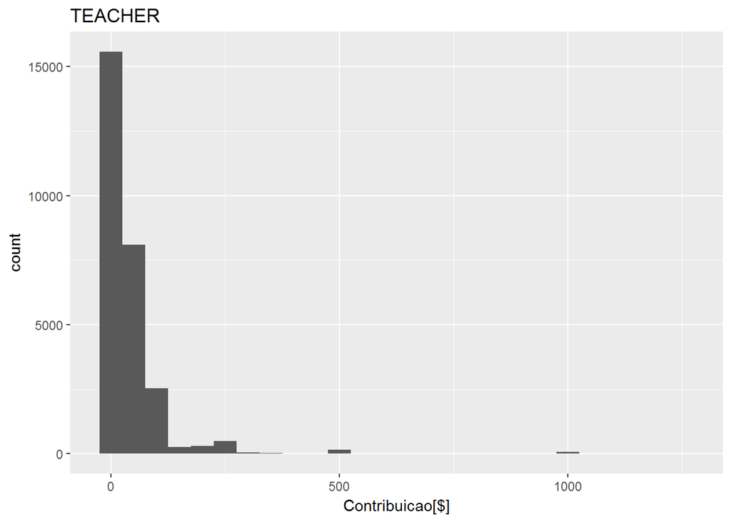

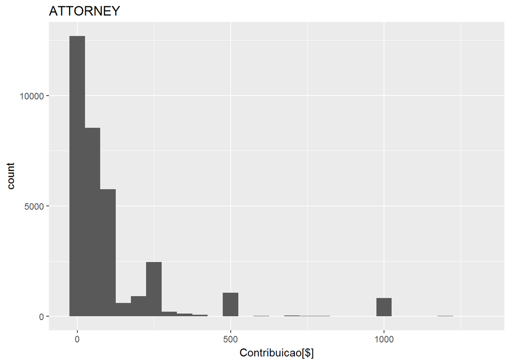

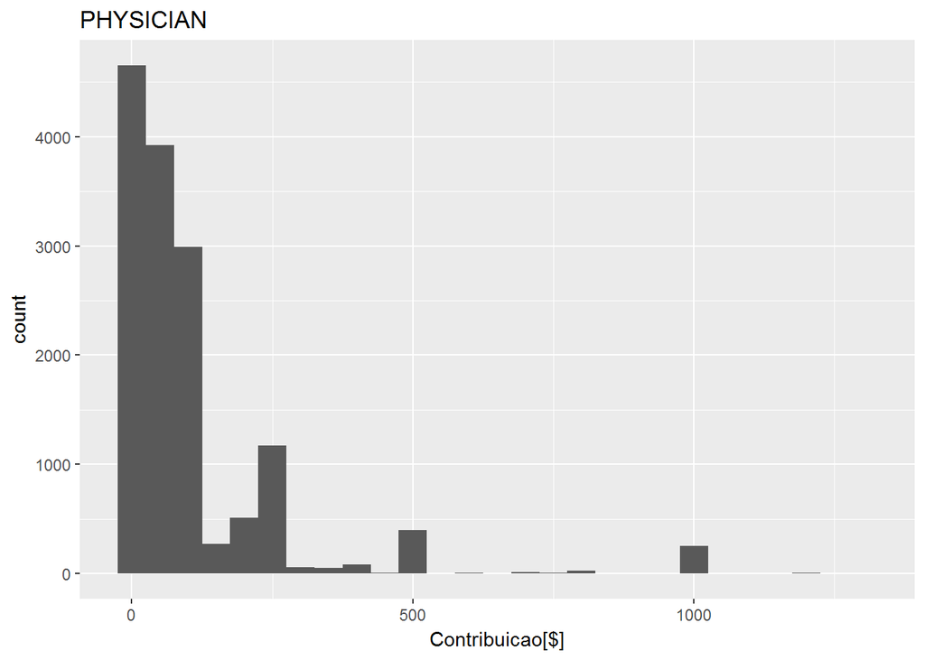

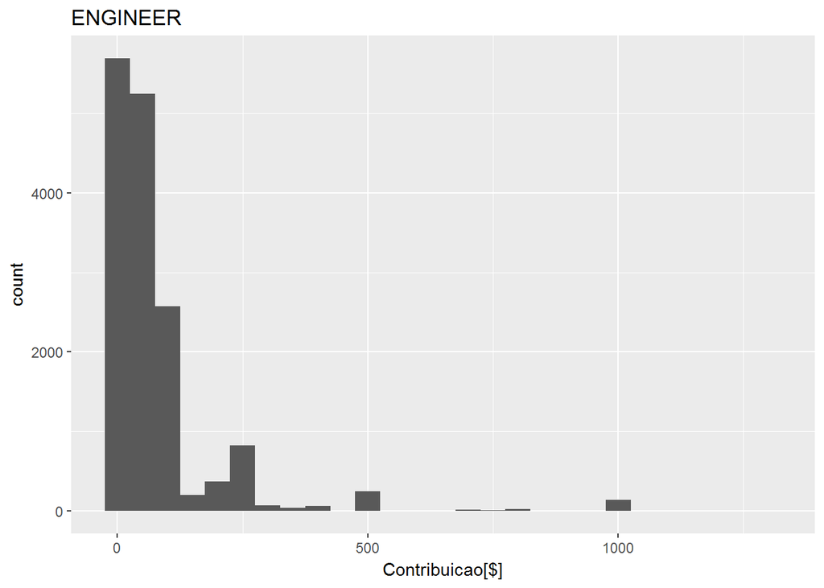

# Grafico das doacoes por ocupacao

Comparando as doacoes por ocupacao atraves de um boxplot vemos que a mediana é maior para **INFORMATION REQUESTED**.

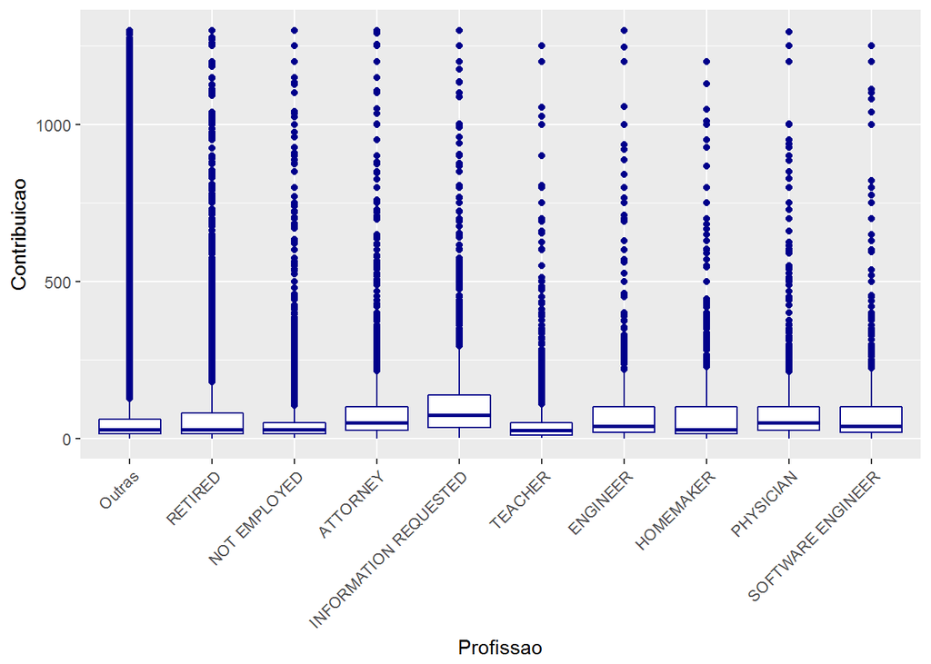

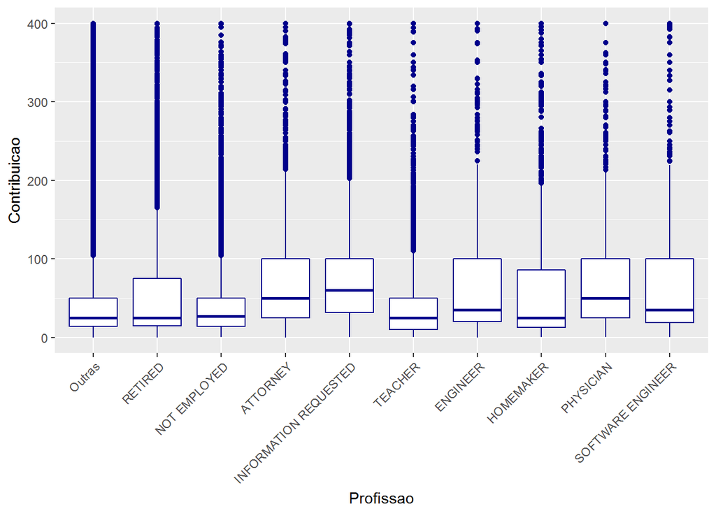

# Analise multivariada

Nas analises anteriores entendemos como as contribuicoes estao chegando nos candidatos e como os doadores estao estao enviando dinheiro de acordo com sua ocupacao. Agora atraves das analises anteriores podemos estudar a relacao candidato, ocupacao e valor da doacao, e analisar esse comportamento durante o periodo de campanha.

Algumas ocupacoes serao escolhidas para o detalhamento descrito acima.

## Doacoes de aposentados

Como os aposentado sao o maior grupo em quantidade de doacoes, vamos o valor doado por aposentados para cada candidato.

Temos pelo grafico que a maioria dos aposentados fez doacoes para Hillary e Sanders. O grafico nao expressa o valor total das doacoes por candidato.

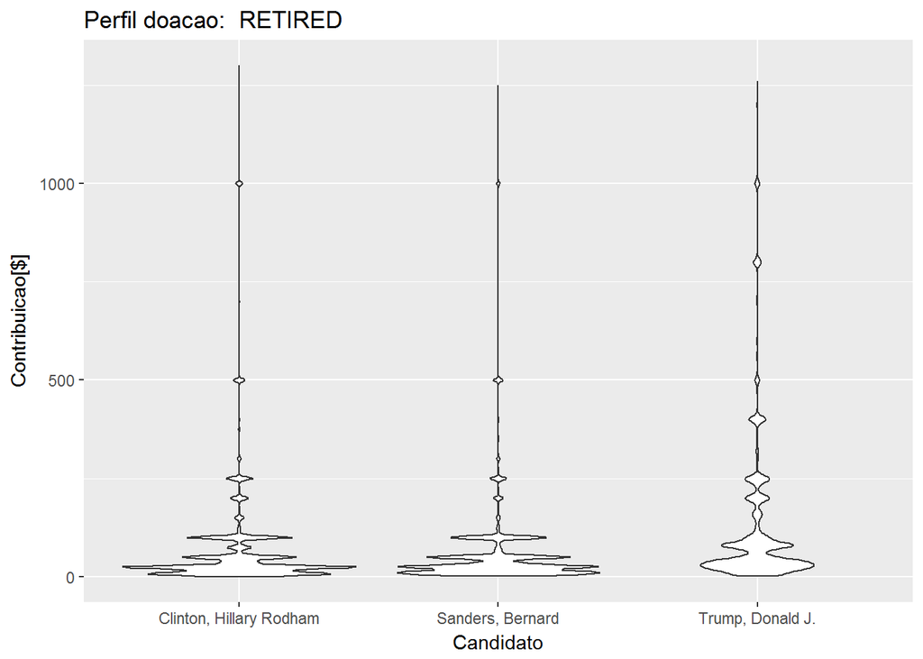

Criando uma tabela que descreva o grafico acima, temos que o valor medio das doacoes de Trump e maior que dos demais candidatos. Isso nao significa que os aposentados mais ricos preferem Trump, primeiro devido a pequena diferenca entre as doacoes e segundo porque nao estamos realizando nenhum teste estatistico.

> Olhando o grafico acima podemos ver que as maiores doacoes financeiras parecem ocorrer para Trump, enquanto as menores ocorrem para os demais.

Com a tabela abaixo vemos que o valor medio das doacoes de Trump e o maior entre os candidatos.

```
## # A tibble: 3 × 6
##                   cand_nm     Media Mediana      Total Contagem Maxima
##                    <fctr>     <dbl>   <dbl>      <dbl>    <int>  <dbl>
## 1        Sanders, Bernard  52.24383      27   856015.2    16385   1250
## 2 Clinton, Hillary Rodham  64.68316      25 10317934.5   159515   1300
## 3        Trump, Donald J. 116.91163      50  3814826.4    32630   1260
```

# Analisando as doacoes dos desempregados

Como os desempregados sao um grande grupo de doadores e sofre pressao economica e um grupo quer mudancas politicas que podem ser sociais ou economicas.

Pelo gráfico e tabela abaixo, vemos que Trump tem pouca popularidade com os desempregados, enquanto Sanders recebeu a maior numero de doacoes, porem com menor valor que Hillary.

A tabela abaixo demonstra essas relacoes.

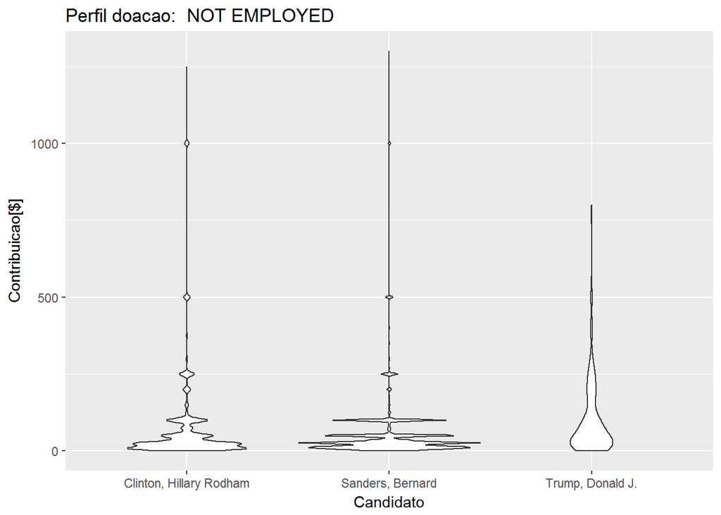

```
## # A tibble: 3 × 5
##                   cand_nm     Media Mediana      Total Contagem
##                    <fctr>     <dbl>   <dbl>      <dbl>    <int>
## 1        Sanders, Bernard  47.96714      27 5062260.13   105536
## 2 Clinton, Hillary Rodham  69.50904      25  662977.18     9538
## 3        Trump, Donald J. 103.79185      50   18474.95      178
```

## Tabela de estatisticas de doacoes agrupadas por candidato e ocupacao

Já está claro a preferencia dos doadores pelos candidatos, assim a arrecadaco absoluta de Trump sera sempre inferior aos demais, mas em termos relativos o valor arrecado por doacao pode mostrar que os apoiadores de Trump realizam maior contribuicao.

Abaixo temos uma analise relativa com tabela e grafico.

| cand_nm | contbr_occupation | Media | Mediana | Total | Contagem |
| --- | --- | --- | --- | --- | --- |
| Clinton, Hillary Rodham | RETIRED | 64.68316 | 25.00 | 10317934.52 | 159515 |
| Sanders, Bernard | RETIRED | 52.24383 | 27.00 | 856015.21 | 16385 |
| Trump, Donald J. | RETIRED | 116.91163 | 50.00 | 3814826.37 | 32630 |
| Clinton, Hillary Rodham | NOT EMPLOYED | 69.50904 | 25.00 | 662977.18 | 9538 |
| Sanders, Bernard | NOT EMPLOYED | 47.96714 | 27.00 | 5062260.13 | 105536 |
| Trump, Donald J. | NOT EMPLOYED | 103.79185 | 50.00 | 18474.95 | 178 |
| Clinton, Hillary Rodham | ATTORNEY | 117.25144 | 50.00 | 3106107.96 | 26491 |
| Sanders, Bernard | ATTORNEY | 74.10554 | 35.00 | 466568.46 | 6296 |
| Trump, Donald J. | ATTORNEY | 190.05682 | 100.00 | 126197.73 | 664 |
| Clinton, Hillary Rodham | INFORMATION REQUESTED | 151.84695 | 100.00 | 2045682.12 | 13472 |
| Sanders, Bernard | INFORMATION REQUESTED | 178.85379 | 100.00 | 288133.46 | 1611 |
| Trump, Donald J. | INFORMATION REQUESTED | 95.34956 | 49.15 | 1424999.18 | 14945 |
| Clinton, Hillary Rodham | TEACHER | 50.23944 | 25.00 | 802725.72 | 15978 |
| Sanders, Bernard | TEACHER | 37.07313 | 25.00 | 415107.82 | 11197 |
| Trump, Donald J. | TEACHER | 89.09158 | 40.00 | 38843.93 | 436 |
| Clinton, Hillary Rodham | ENGINEER | 92.05059 | 50.00 | 642605.19 | 6981 |
| Sanders, Bernard | ENGINEER | 58.79195 | 27.00 | 446230.88 | 7590 |
| Trump, Donald J. | ENGINEER | 174.40533 | 99.56 | 167254.71 | 959 |
| Clinton, Hillary Rodham | HOMEMAKER | 89.37222 | 25.00 | 1019468.95 | 11407 |
| Sanders, Bernard | HOMEMAKER | 48.13213 | 27.00 | 29216.20 | 607 |
| Trump, Donald J. | HOMEMAKER | 140.36627 | 80.00 | 120714.99 | 860 |
| Clinton, Hillary Rodham | PHYSICIAN | 115.80548 | 50.00 | 1116017.37 | 9637 |
| Sanders, Bernard | PHYSICIAN | 74.03869 | 35.00 | 306149.97 | 4135 |
| Trump, Donald J. | PHYSICIAN | 238.56525 | 200.00 | 160554.41 | 673 |
| Clinton, Hillary Rodham | SOFTWARE ENGINEER | 100.04581 | 50.00 | 607077.99 | 6068 |
| Sanders, Bernard | SOFTWARE ENGINEER | 68.17944 | 35.00 | 566298.40 | 8306 |
| Trump, Donald J. | SOFTWARE ENGINEER | 148.38179 | 100.00 | 23147.56 | 156 |

## Grafico de doacao por ocupacao

Vemos que o valor medio das doacoes para Trump e em geral maior e medicos possuem o maior valor medio de doacao.

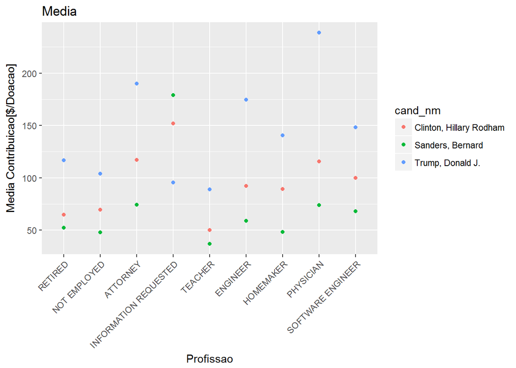

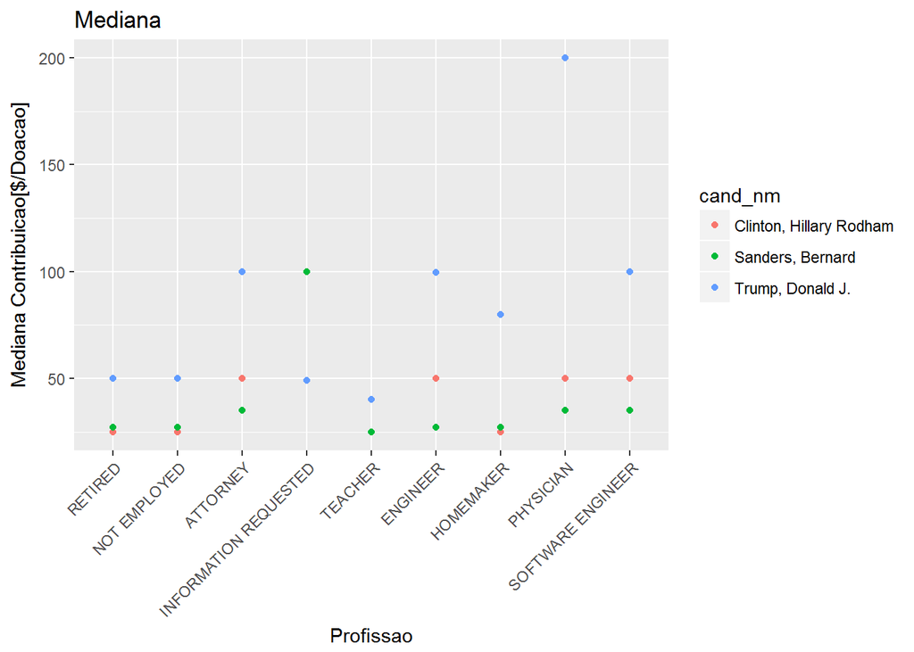

Como comparativo temos que excluindo Hillary do total arrecado vemos que Trump ~34% do valor total com somente ~14% dos doacoes, enquanto Sanders arrecadou ~65% do valor total com ~85% das doacoes.

```
##            cand_nm     Total Contagem
## 1 Sanders, Bernard 0.6559826 0.860025
## 2 Trump, Donald J. 0.3440174 0.139975
```

# Analise temporal

Na analise anterior nos focamos no valor das doacoes para cada candidato vindo de cada ocupacao. Agora nos focamos em entender como as doacoes ocorrem no tempo para cada candidato.

No grafico e interessante como as doacoes ocorrem ao longo do tempo, as doacoes para Hillary ocorrem de forma quase uniforme, enquanto Sanders fica estacionado em uma faixa intermediaria. No caso de Trump as doacoes ocorrem no final do periodo, isso nos faz supor que foi na fase final que ele ganhou popularidade.

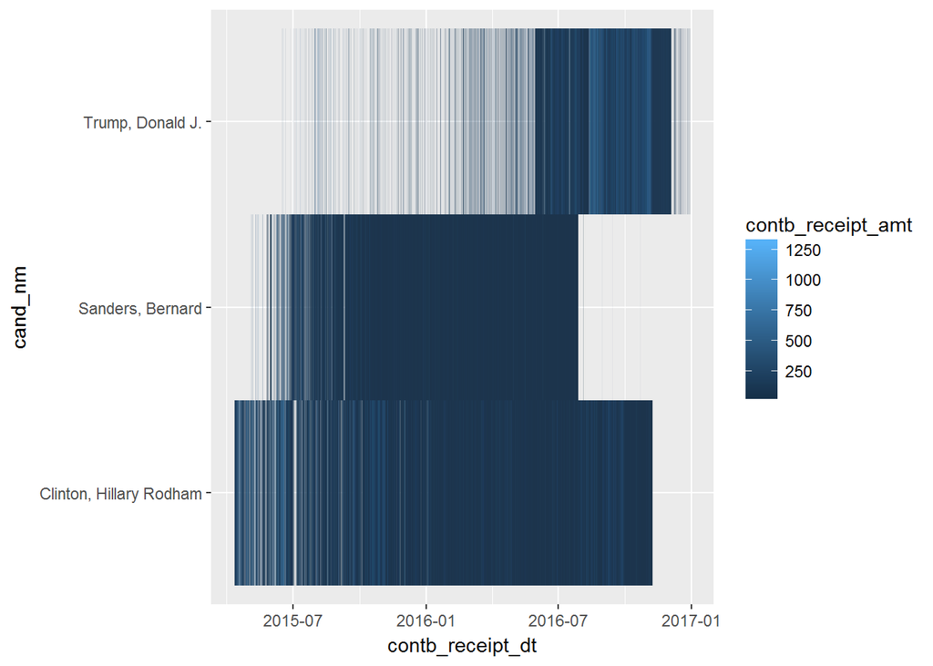

# Gráficos Finais e Sumário

O objetivo desta parte é selecionar 3 gráficos acima e deixá-los mais polidos.

# Gráfico em proporcao

Expandindo a quantidade de informacao no grafico anterior podemos ver como estao as proporcoes em numero de doacoes.

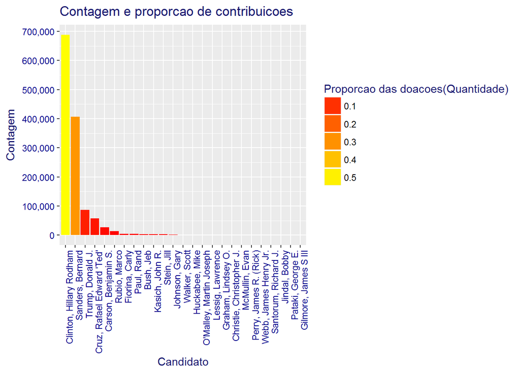

## Grafico Violino

Incrementando a analise anterior, substituimos a porcentagem das doacoes pela analise da quantidade de doacoes por ocupacao.

Fica claro o que foi visto anteriormente sobre valor medio das doacoes e a quantidade de doadores.

Os barras para Trump sao alongadas, porem estreitas, devido as poucas doacoes, mas com valores altos se comparados aos demais candidatos.

Para Hillary e Sanders a forma “gordinha” mostra que numero de contribuintes e grande, mas como a mediana das doacoes nao e alta, temos que sao pouco alongadas.

No caso das doacoes feitas por **physician** o numero de doacoes para Trump é muito pequena.

Uma analise de interesse seria analisar como essas doacoes ocorrem no tempo, o que poderia nos ajudar a identificar se as doacoes de um candidato ocorrem em um periodo especifico das doacoes.

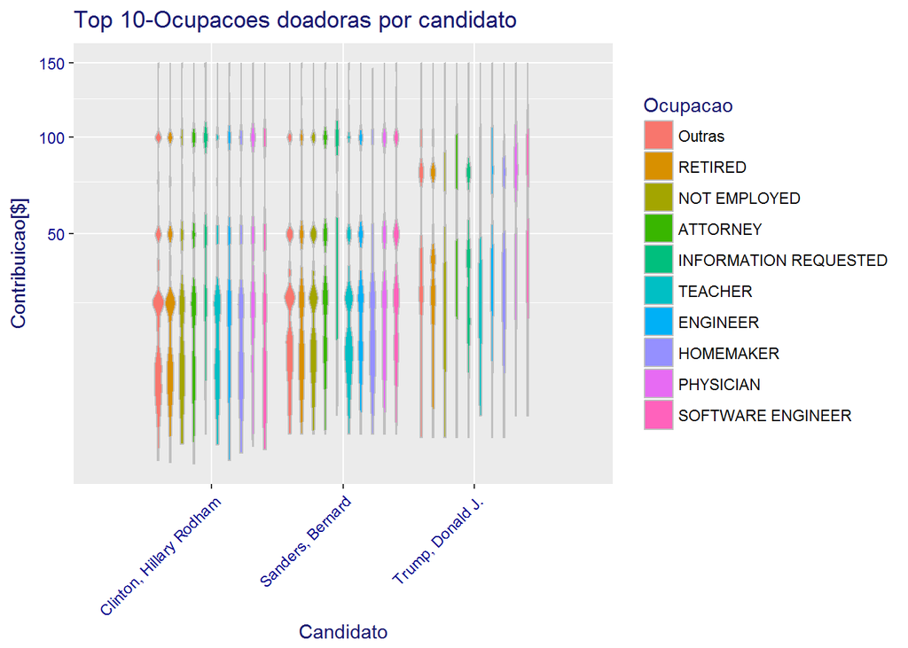

# Analise temporal

Anteriomente analisamos a proporcao das doacoes de cada candidato e em seguida para os 3 mais representativos, analisamos as ocupacoes e com que valores elas contribuem para cada candidato.

Identificar o valor total doado diariamente para cada candidato, mostra o apoio no decorrer do periodo dos doadores durante o periodo de doacao.

Vemos que Sanders recebe doacao no meio do periodo, enquanto Hillary recebe contribuicoes durante quase todo o periodo e Trump nos meses finais. O detalhe que Sanders e Hillary recebem um grande volume de doacoes no mesmo periodo, enquanto as doacoes de Sanders caem e as de Trump comecam a crescer, podemos supor que existe uma mudanca do eleitorado de Sanders na direcao de Trump e Hillary, sendo que estes foram os principais candidatos.

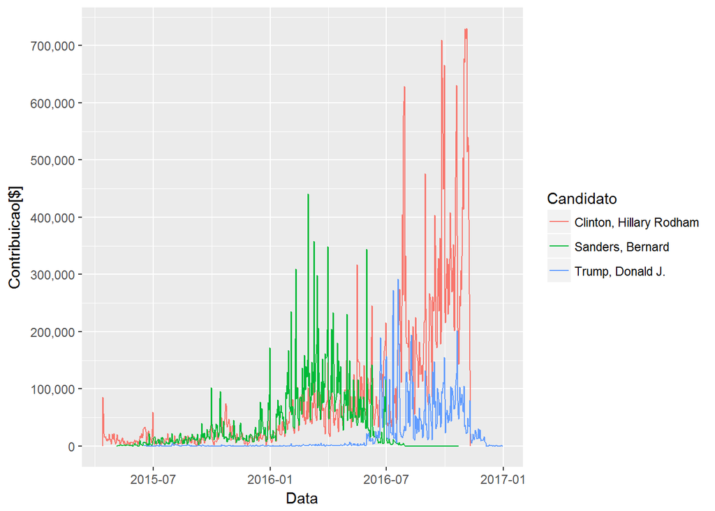

# Reflexoes

### Ideias futuras

Uma informacao que nao foi explorada na base de dados e as doacoes por genero. Para realizar essa analise temos de pegar o nome do doador e analisar se o primeiro nome e um nome masculino ou feminino, assim teriamos um comparativo de como homens e mulheres fazem doacoes e qual a ocupacao destes doadores.

Como temos os nomes das cidades podemos fazer a geoanalise da origem das doacoes por candidato. A variavel “employer” tambem poderia nos fornecer informacoes se existe um tendencia de doacao dentro de um determinado setor, mas para isso precisariamos de uma base auxiliar que nos desse o setor da empresa.

O ultimo grafico pode ser alterado para fornecer informacoe do fluxo de doacoes para cada um dos 3 candidatos principais que segregamos.

### Sucessos

Tivemos sucesso em entender como as doacoes ocorrem por ocupacao, valor doado e os candidatos preferidos, alem do valor medio, mediano e total doado para os 3 principais candidatos e complementamos com uma analise de doacao no tempo por ocupacao. Enumerando o que foi encontrado:

1. 75% das doacoes são até $99 e 95% até $400
2. Acima de $1300 considerando outliers
3. Identficamos que a grande maioria das doacoes sao os candidatos Hillary, Sanders e Trump
4. As doacoes variam no tempo, tendo dois picos no inicio e final do periodo enquanto que no periodo intermediario ocorre uma queda
5. Aposentados e desempregados sao os principais doadores
6. Em geral a maioria das doacoes de qualquer ocupacao se concentra em $0-$50, mas no caso dos doadores que **nao declararam** as faixas $50-$100 e $100-$150 sao maiores
7. Trump teve o menor numero de doacoes
8. Trump teve o maior valor medio por doacao
9. A analise temporal mostra que Trump recebeu a maioria das doacoes nos ultimos meses de 2016

### Dificuldades

A base de dados nao traz grandes dificuldades devido a seu formato, mas a falta de informacao sobre a ocupacao prejudica a analise. O campo “INFORMATION REQUESTED” e a quarta ocupacao que mais aparece.

O tamanho da base de dados deixa a renderizacao dos graficos lenta em algus casos.

A falta da informacao de genero na base impede analises interessantes sobre genero e seu impacto nas doacoes.